# Chapter 8 In-Class R Demo: SARIMA

## Demo Goal

You will see how seasonal differencing and seasonal ARMA terms help model repeating patterns.

Reference anchor: seasonal ARIMA modelling and seasonal ACF/PACF diagnostics.

```r
set.seed(311)
par(mfrow = c(1, 1))
```

## 1. Built-In Seasonal Series

Start with the plots. The seasonal swings grow as the passenger counts grow, so we compare the original data with their logarithms before choosing differences or fitting a model.

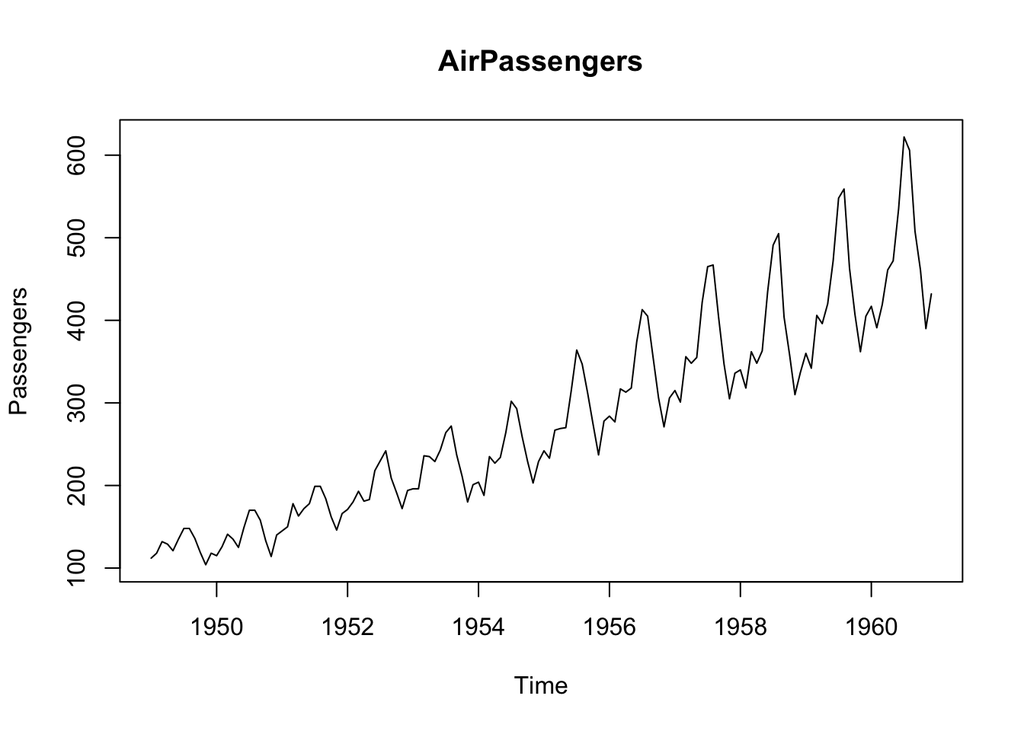

```r
plot(AirPassengers, main = "AirPassengers", ylab = "Passengers")
```

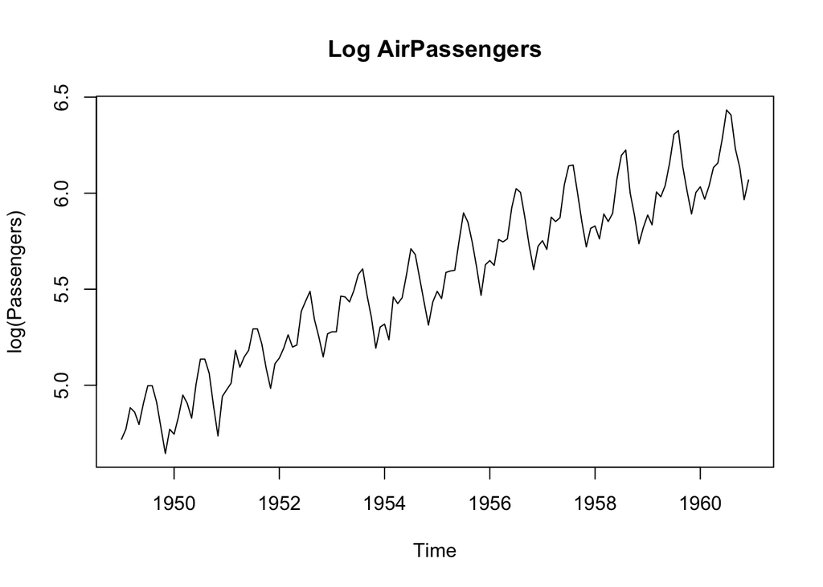

```r
plot(log(AirPassengers), main = "Log AirPassengers", ylab = "log(Passengers)")
```

Questions:

- Why is the log transform useful before SARIMA modelling?

What the commands do:

- `AirPassengers` is a built-in monthly series with frequency 12.
- `plot()` uses its stored dates to label the horizontal axis.
- `log()` reduces the increase in seasonal amplitude as the level grows. It does not by itself remove trend or seasonality.

## 2. Seasonal Differencing

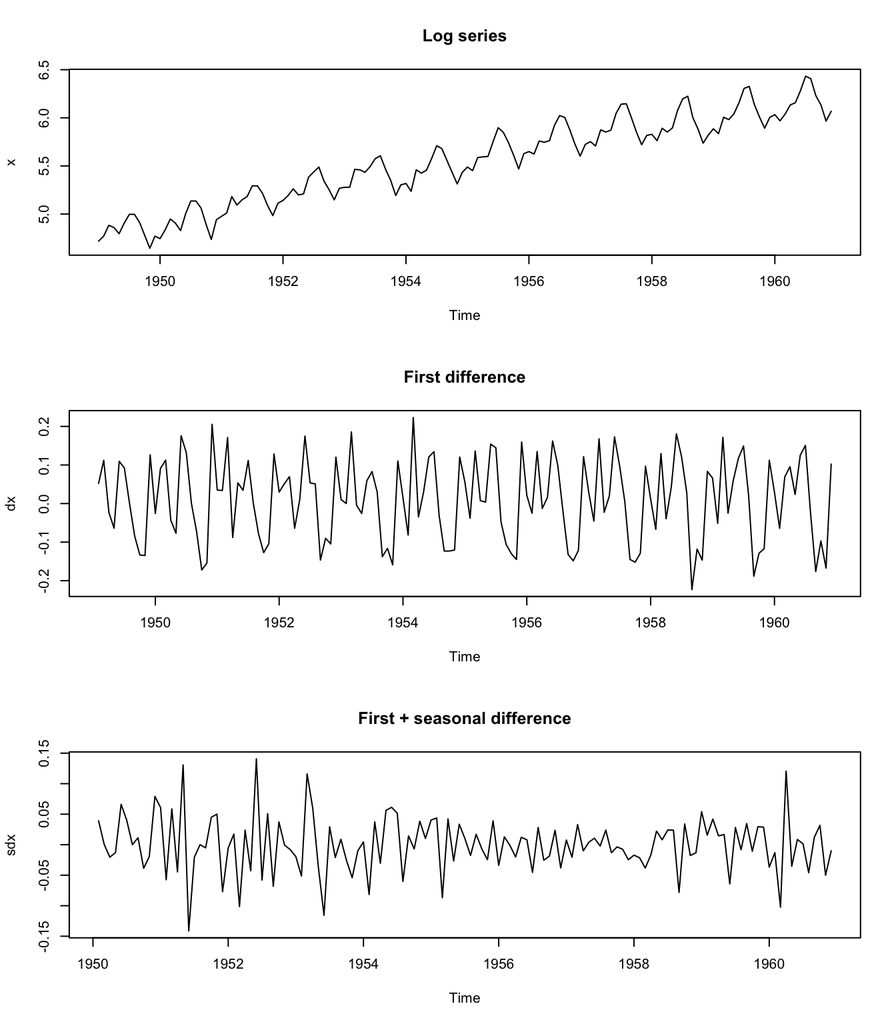

```r
x <- log(AirPassengers)
dx <- diff(x)
sdx <- diff(dx, lag = 12)

par(mfrow = c(3, 1))
plot.ts(x, main = "Log series")
plot.ts(dx, main = "First difference")
plot.ts(sdx, main = "First + seasonal difference")
```

```r
par(mfrow = c(1, 1))
```

Questions:

- Which transformation removes trend?
- Which transformation removes annual seasonality?

What the commands do:

- `diff(x)` forms $\nabla x_t = x_t - x_{t-1}$.
- `diff(dx, lag = 12)` then forms $\nabla_{12}\nabla x_t = (x_t - x_{t-1}) - (x_{t-12} - x_{t-13})$.
- The two operations remove 13 initial observations altogether.

### Compare the Seasonal Lag Before and After Differencing

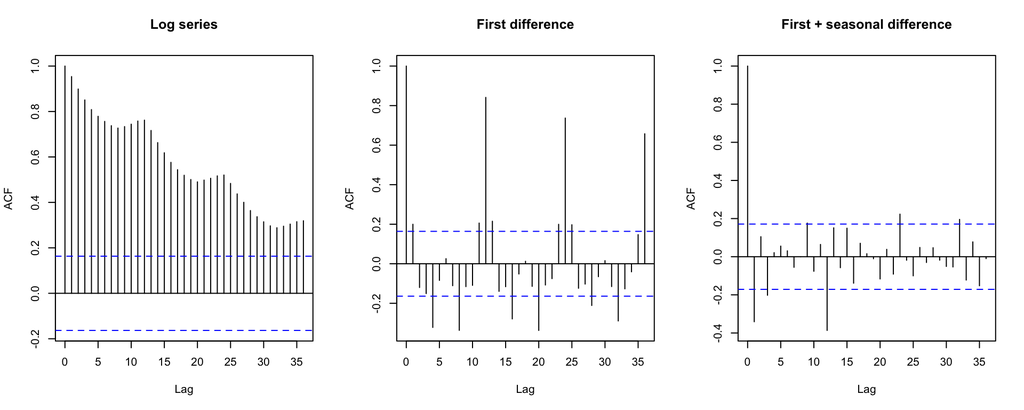

```r
par(mfrow = c(1, 3))
acf(as.numeric(x), lag.max = 36, main = "Log series")
acf(as.numeric(dx), lag.max = 36, main = "First difference")
acf(as.numeric(sdx), lag.max = 36, main = "First + seasonal difference")
```

```r
par(mfrow = c(1, 1))
c(log_series = length(x), first_difference = length(dx),
  both_differences = length(sdx))
```

```
##       log_series first_difference both_differences
##              144              143              131
```

Questions:

- After first differencing, is there still a pattern at lags 12, 24 and 36?
- After both differences, must every sample autocorrelation be zero?
- How is remaining short-lag dependence different from a slow seasonal decay?

## 3. Seasonal ACF/PACF

`as.numeric()` makes R count the lags in months rather than years.

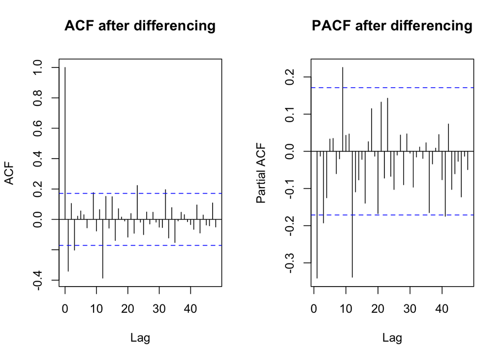

```r
par(mfrow = c(1, 2))
acf(as.numeric(sdx), lag.max = 48, main = "ACF after differencing")
pacf(as.numeric(sdx), lag.max = 48, main = "PACF after differencing")
```

```r
par(mfrow = c(1, 1))
```

Questions:

- What happens at lag 12?
- Does the seasonal pattern look AR-like or MA-like?

The horizontal axis now counts months. The seasonal lags are 12, 24, 36 and 48; lag 1 is one month, not one year. Use these plots to propose a model, then check its fitted residuals.

Try it yourself:

- Replace `sdx` by `dx` in the two diagnostic plots. Which seasonal pattern is stronger before seasonal differencing?

## 4. Fit a Simple SARIMA Model

```r
fit <- arima(
  x,
  order = c(0, 1, 1),
  seasonal = list(order = c(0, 1, 1), period = 12)
)
fit
```

```
##
## Call:
## arima(x = x, order = c(0, 1, 1), seasonal = list(order = c(0, 1, 1), period = 12))
##
## Coefficients:
##           ma1     sma1
##       -0.4018  -0.5569
## s.e.   0.0896   0.0731
##
## sigma^2 estimated as 0.001348:  log likelihood = 244.7,  aic = -483.4
```

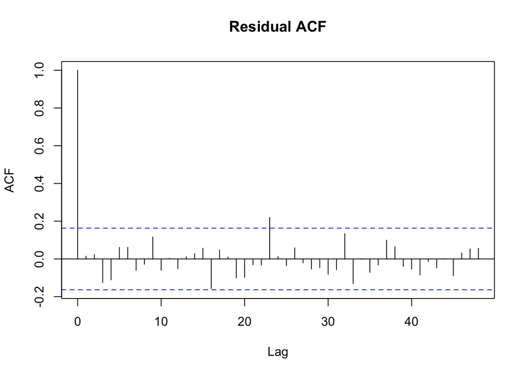

```r
acf(as.numeric(residuals(fit)), lag.max = 48, main = "Residual ACF")
```

```r
# fitdf = p + q + P + Q = 2
Box.test(residuals(fit), lag = 24, type = "Ljung-Box", fitdf = 2)
```

```
##
##  Box-Ljung test
##
## data:  residuals(fit)
## X-squared = 26.446, df = 22, p-value = 0.233
```

What the commands do:

- `order = c(0, 1, 1)` sets $(p,d,q)$ for the nonseasonal part.
- `seasonal = list(order = c(0, 1, 1), period = 12)` sets $(P,D,Q)$ and the seasonal period. R applies both differences to `x` internally.
- Fit the log series `x`, not the already differenced `sdx`, with these orders.
- `fitdf = 2` counts one nonseasonal and one seasonal MA coefficient.

### Read the Multiplicative Model

Multiplying the two MA factors gives

$$(1 - \theta B)(1 - \Theta B^{12})
= 1 - \theta B - \Theta B^{12} + \theta\Theta B^{13}.$$

The lag-13 term is determined by the two fitted MA coefficients; it is not a third free coefficient.

```r
theta_hat <- -unname(coef(fit)["ma1"])
Theta_hat <- -unname(coef(fit)["sma1"])
data.frame(
  lag = c(1, 12, 13),
  shock_coefficient = c(-theta_hat, -Theta_hat, theta_hat * Theta_hat)
)
```

```
##   lag shock_coefficient
## 1   1        -0.4018279
## 2  12        -0.5569448
## 3  13         0.2237960
```

Questions:

- How does the product term help explain an ACF feature near lag 13?
- Why are we fitting two MA coefficients rather than three unrelated ones?

Questions:

- R’s `ma1` and `sma1` are $-\hat\theta$ and $-\hat\Theta$ for the model $\nabla\nabla_{12}\log X_t = (1 - \theta B)(1 - \Theta B^{12})\epsilon_t$. What are $\hat\theta$ and $\hat\Theta$?
- Do the residuals behave like white noise?

## 5. Forecast on the Original Scale

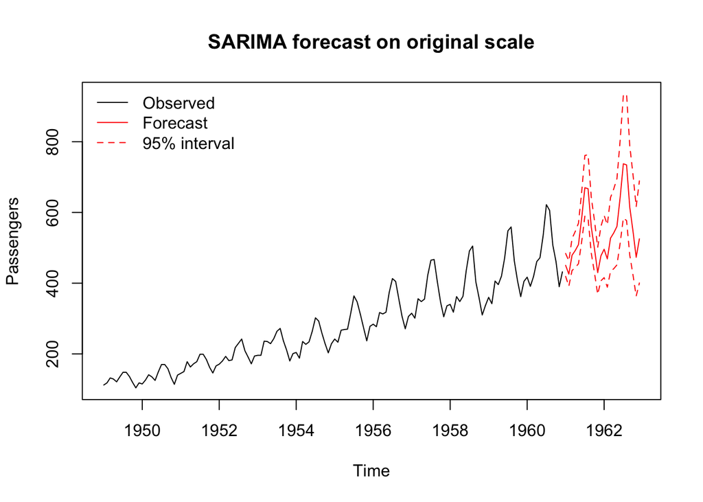

```r
pred <- predict(fit, n.ahead = 24)
future_log <- pred$pred
future <- exp(future_log)       # conditional median (notes, Section 5.1)
lower <- exp(future_log - 1.96 * pred$se)   # 95% prediction limits
upper <- exp(future_log + 1.96 * pred$se)

ts.plot(AirPassengers, future, lower, upper,
        col = c("black", "red", "red", "red"), lty = c(1, 1, 2, 2),
        main = "SARIMA forecast on original scale",
        ylab = "Passengers")
legend("topleft", legend = c("Observed", "Forecast", "95% interval"),
       col = c("black", "red", "red"), lty = c(1, 1, 2), bty = "n")
```

Questions:

- Why is `exp(pred$pred)` the median, not the mean, of the forecast distribution?
- Why are the prediction limits not symmetric about the forecast?

What the commands do:

- `predict()` works on the fitted log scale.
- `exp()` transforms each forecast and each endpoint back to passenger counts.
- With a normal forecast distribution on the log scale, the exponentiated log forecast is the median. Exponentiating the endpoints preserves their approximate coverage, but makes the interval asymmetric.

### Compare the Median with the Mean

Under that normal assumption, the corresponding mean uses the variance adjustment described in the notes:

```r
future_mean <- exp(future_log + 0.5 * pred$se^2)
data.frame(
  horizon = 1:6,
  median = round(as.numeric(future)[1:6], 1),
  mean = round(as.numeric(future_mean)[1:6], 1),
  lower = round(as.numeric(lower)[1:6], 1),
  upper = round(as.numeric(upper)[1:6], 1)
)
```

```
##   horizon median  mean lower upper
## 1       1  450.4 450.7 419.1 484.0
## 2       2  425.7 426.1 391.5 463.0
## 3       3  479.0 479.6 435.9 526.4
## 4       4  492.4 493.1 443.9 546.2
## 5       5  509.1 509.9 455.0 569.5
## 6       6  583.3 584.4 517.3 657.8
```

Questions:

- Why is the mean larger than the median here?
- What happens to the difference as the forecast variance grows?

Try it yourself:

- Change the forecast horizon to `36`. Do the seasonal peaks continue?
- Compare interval widths on the log scale and the passenger scale.
- Explain why a plausible seasonal forecast still needs residual checks.